# Cyclistic Year Report

Youi

2024-04-19

## Introduction

#### Scenario

Cyclistic is a bike-share program that features more than 5,800 bicycles and 600 docking stations. Finance analysts have concluded that annual members are much more profitable than casual riders. Hence, the director of marketing has set the goal:Design marketing strategies aimed at converting casual riders into annual members. In order to do that, the marketing analyst team needs to better understand how annual members and casual riders differ. Raw data of Cyclistic trip can be found [here](https://divvy-tripdata.s3.amazonaws.com/index.html).

## Descriptive analysis

#### Summary

The previous 12 months of Cyclistic trip data, June 2021 till May 2022, has 5,860,776 rows. 646 rows travel time (variable duration) are smaller than 0. After removing those data, 5,860,130 rows are left.

#### NA values

Only variable start_station_id, start_station_name, end_station_id, end_station_name, end_lat, end_lng have NA values. First four variables can be substituted by position variables(lat and lng). Last two variables’ NA is not big portion to the whole data.

Data summary

| Name | Piped data |
| --- | --- |
| Number of rows | 5860130 |
| Number of columns | 28 |
| _______________________ |  |
| Column type frequency: |  |
| character | 5 |
| difftime | 3 |
| factor | 3 |
| numeric | 12 |
| POSIXct | 5 |
| ________________________ |  |
| Group variables | None |

**Variable type: character**

| skim_variable | n_missing | complete_rate | min | max | empty | n_unique | whitespace |
| --- | --- | --- | --- | --- | --- | --- | --- |
| ride_id | 0 | 1.00 | 16 | 16 | 0 | 5860130 | 0 |
| start_station_name | 823145 | 0.86 | 3 | 53 | 0 | 1105 | 0 |
| start_station_id | 823142 | 0.86 | 3 | 44 | 0 | 1063 | 0 |
| end_station_name | 877927 | 0.85 | 9 | 53 | 0 | 1112 | 0 |
| end_station_id | 877927 | 0.85 | 3 | 44 | 0 | 1068 | 0 |

**Variable type: difftime**

| skim_variable | n_missing | complete_rate | min | max | median | n_unique |
| --- | --- | --- | --- | --- | --- | --- |
| started_hms | 0 | 1 | 0 secs | 86399 secs | 55914 secs | 86370 |
| ended_hms | 0 | 1 | 0 secs | 86399 secs | 56760 secs | 86383 |
| duration | 0 | 1 | 1 secs | 3356649 secs | 681 secs | 24839 |

**Variable type: factor**

| skim_variable | n_missing | complete_rate | ordered | n_unique | top_counts |
| --- | --- | --- | --- | --- | --- |
| Bikes | 0 | 1 | FALSE | 3 | cla: 3217479, ele: 2368211, doc: 274440 |
| Users | 0 | 1 | FALSE | 2 | mem: 3300629, cas: 2559501 |
| wday | 0 | 1 | TRUE | 7 | Sat: 987105, Sun: 864748, Fri: 819735, Tue: 811755 |

**Variable type: numeric**

| skim_variable | n_missing | complete_rate | mean | sd | p0 | p25 | p50 | p75 | p100 |
| --- | --- | --- | --- | --- | --- | --- | --- | --- | --- |
| start_lat | 0 | 1 | 41.90 | 0.05 | 41.64 | 41.88 | 41.90 | 41.93 | 45.64 |
| start_lng | 0 | 1 | -87.65 | 0.03 | -87.84 | -87.66 | -87.64 | -87.63 | -73.80 |
| end_lat | 5036 | 1 | 41.90 | 0.05 | 41.39 | 41.88 | 41.90 | 41.93 | 42.17 |
| end_lng | 5036 | 1 | -87.65 | 0.03 | -88.97 | -87.66 | -87.64 | -87.63 | -87.49 |
| year | 0 | 1 | 2021.26 | 0.44 | 2021.00 | 2021.00 | 2021.00 | 2022.00 | 2022.00 |
| month | 0 | 1 | 7.25 | 2.58 | 1.00 | 5.00 | 7.00 | 9.00 | 12.00 |
| day | 0 | 1 | 15.54 | 8.69 | 1.00 | 8.00 | 15.00 | 23.00 | 31.00 |
| hour | 0 | 1 | 14.21 | 5.07 | 0.00 | 11.00 | 15.00 | 18.00 | 23.00 |
| start_lng_rd | 0 | 1 | -87.65 | 0.03 | -87.84 | -87.66 | -87.64 | -87.63 | -73.80 |
| start_lat_rd | 0 | 1 | 41.90 | 0.05 | 41.64 | 41.88 | 41.90 | 41.93 | 45.64 |
| end_lng_rd | 5036 | 1 | -87.65 | 0.03 | -88.97 | -87.66 | -87.64 | -87.63 | -87.49 |
| end_lat_rd | 5036 | 1 | 41.90 | 0.05 | 41.39 | 41.88 | 41.90 | 41.93 | 42.17 |

**Variable type: POSIXct**

| skim_variable | n_missing | complete_rate | min | max | median | n_unique |
| --- | --- | --- | --- | --- | --- | --- |
| started_at | 0 | 1 | 2021-06-01 00:00:38 | 2022-05-31 23:59:56 | 2021-09-23 17:33:16 | 4896398 |
| ended_at | 0 | 1 | 2021-06-01 00:06:22 | 2022-06-02 11:35:01 | 2021-09-23 17:49:24 | 4893051 |
| year_month | 0 | 1 | 2021-06-01 00:00:00 | 2022-05-01 00:00:00 | 2021-09-01 00:00:00 | 12 |
| started_round | 0 | 1 | 2021-06-01 00:01:00 | 2022-06-01 00:00:00 | 2021-09-23 17:33:00 | 461901 |
| ended_round | 0 | 1 | 2021-06-01 00:06:00 | 2022-06-02 11:35:00 | 2021-09-23 17:49:00 | 462441 |

## Visualize the data

### 1.Usage

Check on the usage of the previous 12 months :  
Member users used classic bikes more often than electrics. Casual users used classic slightly more often than electric bikes (48% and 41%).

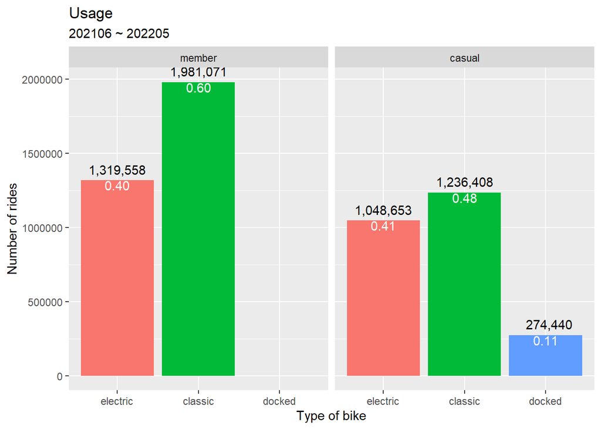

Assumption in **bold**:

1. Members are limited to classic and electric usage.
2. Members commuted in **short distance**, using classic bike more often, classic bike is more **cheap**.
3. Casuals used **electric bike** to travel **far** **on weekends**.
4. Casuals rode bikes **for leisure**.

#### Usage per month

During the previous 12 months (June 2021 till May 2022), usage varied a lot with months. The total number of rides reached highest at around July and August. Fewer users used the bike, especially for casual member, during winter. The total number of rides reached lowest at January.

Member riders had higher classic bikes usage (266,818) before September 2021, almost twice the number of electric bikes (125,439). After October 2021, usage of both classic and electric bikes started to drop, and hit lowest point (48,093 and 37,157) at January 2022. Usage increased almost at the same speed of dropping and reached 197,971 and 156,472 for classic and electric bikes at May 2022.

Casual riders had higher classic bikes usage (241,489) before July 2021, almost twice the number of electric bikes (142,869). After October 2021, usage of both classic and electric bikes started to drop, and hit lowest point (6,974 and 10,585) at January 2022. Usage increased almost at the same speed of dropping and reached 126,075 and 127,931 for classic and electric bikes at May 2022.

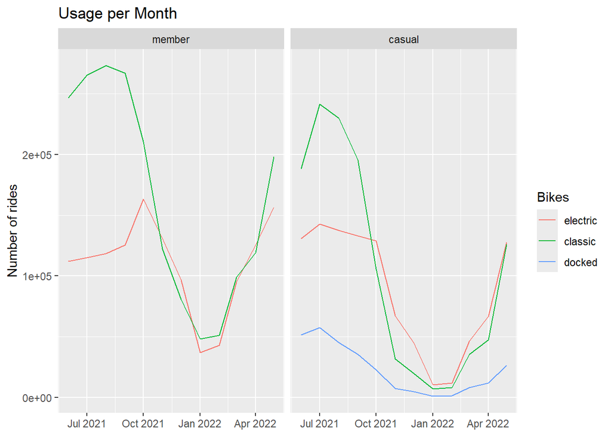

#### Usage per day

Relatively speaking, in member users group, they used bikes more frequently during weekdays, while casual users used more frequently on weekends. Besides, casual users have higher number of rides than member users’ on weekends.

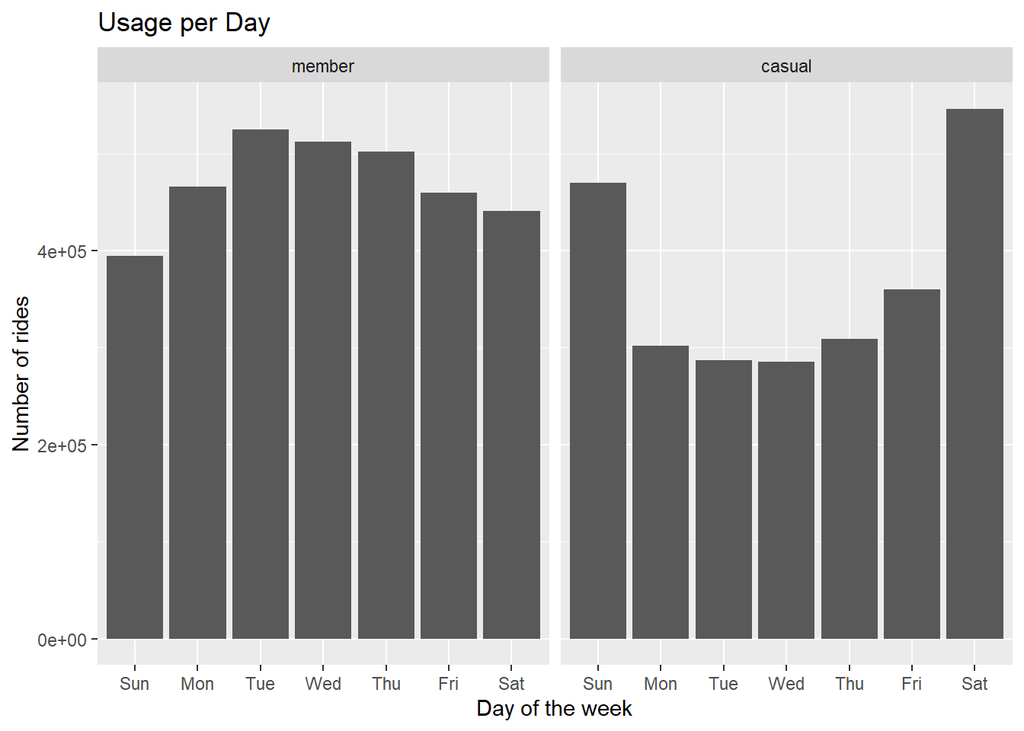

#### Usage per hour

There are two peaks for member users, around 8:00 and 17:00, while casual users’ two peaks are around 1:15 and 17:00. Those who use bike around 1:15 use classic bike for long distance travel, long duration, like road trip.

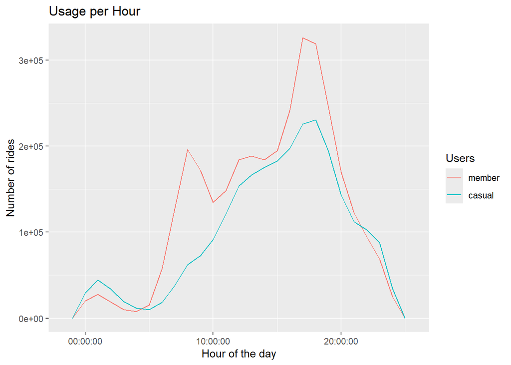

### 2.Travel time

Few users used bikes more than 24 hours.

```
## # A tibble: 8 × 4
## # Groups:   Users, Bikes [5]
##   Users  Bikes    duration_less_than_24h       n
##   <fct>  <fct>                     <dbl>   <int>
## 1 member electric                      1 1319558
## 2 member classic                       0     534
## 3 member classic                       1 1980537
## 4 casual electric                      1 1048653
## 5 casual classic                       0    2459
## 6 casual classic                       1 1233949
## 7 casual docked                        0    1413
## 8 casual docked                        1  273027
```

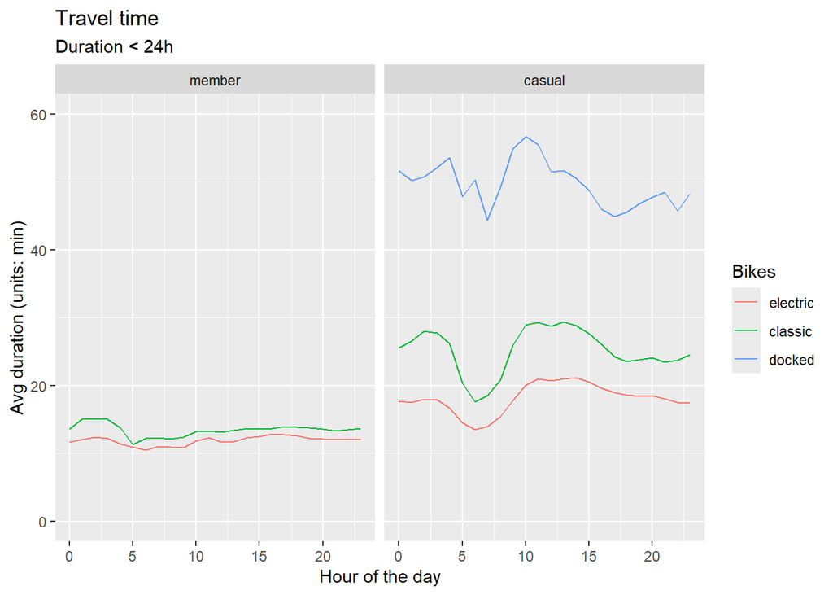

### 3.Position

Ending point is more far-spread than starting point. Casual user spread even more widely. The size of circle based on number of rides.

[interactive chart not shown]

Visualize the top 30 starting and ending stations on the map. Part of member users used bike near The University of Chicago(Hyde Park district). Casual users tended to used bike closer to the Chicago Harbor.

[interactive chart not shown]

## Conclusion

To enhance the biking experience for both members and casual users, the company could consider implementing several suggestions and actions. Firstly, providing incentives or discounts for members who use bikes more frequently could encourage greater adoption among this group. Additionally, offering maintenance services or bike-sharing programs specifically tailored to short-distance commuters could further incentivize bike usage among members. For casual users, introducing special weekend packages or promotions for docked bike rentals could attract more customers looking to explore farther destinations during their leisure time. Furthermore, organizing group biking events or tours on weekends could tap into the leisure aspect of biking and attract both members and casuals alike. Lastly, analyzing seasonal trends in bike usage could inform strategic planning, such as adjusting bike availability or promotional efforts during peak riding seasons to maximize engagement. By implementing these suggestions, the company can promote biking as a convenient, enjoyable, and sustainable mode of transportation for all its users.